# Exploratory Data Analysis of Survey Data

Eric Leung

2018-09-12

# Overview

This report serves as an initial look at freeCodeCamp’s 2018 New Coder Survey data.

This data has not been pre-processed in any way. Thus, this report also serves to explore necessary pre-processing to clean the data.

In exploring possible pre-processing steps, I will try to create thresholds and rules on filtering out data that I find disingenuous for the sake of keeping the integrity of the data high. So possible reasons for removing a row (i.e. a unique survey submission from the final dataset) are

- Extremely high or low answers
- Submitting irrelevant answers

**Last Updated**: Fri Dec 14 10:03:49 2018

# Load Packages

```r
# General help on manipulating data and visualize
library(tidyverse)
library(here)
# More specialized exploration tools
library(Hmisc)
```

# Read in Data

Let’s read in the data.

```r
# Read in data
raw_data_path <- here("raw-data", "2018-New-Coders-Survey.csv")
raw_data <- read_csv(raw_data_path)
```

[output not shown]

```r
# Explore dimensions
data_dim <- dim(raw_data)
```

Just a general check, there were **31149 rows** and **136 columns** in the raw data.

# Remove Basic Columns

Here, let’s remove some columns we know will not be useful in the final dataset.

- Unique ID (unnecessary in the final dataset as we’ll assume each row is independent individual)

This variable is encoded with the `#` symbol.

```r
# Remove unique ID column
raw_data <- raw_data %>% select(-"#")
```

# Explore Data

## Initial Overview

With all the data of interest at hand, let’s do a very simple exploration of the data using the `Hmisc` function `describe()`.

This function goes through each variable and gives a summary that is data-type specific.

```r
# Basic overview of the data
Hmisc::describe(raw_data)
```

```
raw_data

 135  Variables      31149  Observations
--------------------------------------------------------------------------------------------
Are you already working as a software developer?
       n  missing distinct     Info      Sum     Mean      Gmd
   30770      379        2    0.412     5055   0.1643   0.2746

--------------------------------------------------------------------------------------------
Is this your first software development job?
       n  missing distinct     Info      Sum     Mean      Gmd
    5014    26135        2    0.731     2908     0.58   0.4873

--------------------------------------------------------------------------------------------
Before you got this job, how many months did you spend looking for a job?
       n  missing distinct     Info     Mean      Gmd      .05      .10      .25      .50
    4874    26275       43    0.976    4.219    5.473        0        0        1        2
     .75      .90      .95
       5       10       12

lowest :   0   1   2   3   4, highest: 123 200 300 365 500
--------------------------------------------------------------------------------------------
Would you prefer to...
       n  missing distinct
   25690     5459        7

freelance (5253, 0.204), start your own business (5121, 0.199), work for a government (969,
0.038), work for a medium-sized company (5203, 0.203), work for a multinational corporation
(4291, 0.167), work for a nonprofit (1352, 0.053), work for a startup (3501, 0.136)
--------------------------------------------------------------------------------------------
Full-Stack Web Developer
                       n                  missing                 distinct
                    7920                    23229                        1
                   value
Full-Stack Web Developer

Value      Full-Stack Web Developer
Frequency                      7920
Proportion                        1
--------------------------------------------------------------------------------------------
```

[output cut: 1014 more lines]

```
                .25                 .50                 .75                 .90
2018-08-16 15:44:43 2018-09-05 23:24:27 2018-09-27 13:54:27 2018-10-11 13:49:22
                .95
2018-10-16 10:54:17

lowest : 2018-08-02 04:46:07 2018-08-02 23:30:33 2018-08-03 04:51:08 2018-08-03 04:55:14 2018-08-03 04:55:58
highest: 2018-10-24 18:03:42 2018-10-24 18:48:54 2018-10-24 19:14:08 2018-10-24 20:05:57 2018-10-24 20:55:53
--------------------------------------------------------------------------------------------
Network ID
       n  missing distinct
   31149        0    30541

lowest : 00008fa38e 0000b4f3c8 00039ca4dd 00044d0381 00080f0dc9
highest: fff762736f fff8147ab0 fffaea1886 fffe0801b6 fffe66ff56
--------------------------------------------------------------------------------------------
```

From this output, here are some notes about the data that will have to be addressed in the pre-processing step.

- For lots of the data, it was encoded as a `1` or `0`, when it really should have been a boolean value `TRUE` or `FALSE`. Here are the columns that need this treatment.
  - “Are you already working as a software developer?”
  - “Is this your first software development job?”
  - “Are you willing to relocate for a job?”
  - “Have you attended a full-time coding bootcamp?”
  - “Have you finished yet?”
  - “Did you take a loan to pay for the bootcamp?”
  - “Based on your experience, would you recommend this bootcamp to your friends?”
  - “Are you an ethnic minority in your country?”
  - “Do you financially support any dependents?”
  - “Do you have children?”
  - “Do you financially support any elderly relatives or relatives with disabilities?”
  - “Do you have any debt?”
  - “Do you have a home mortgage?”
  - “Do you have student loan debt?”
  - “Do you consider yourself under-employed?”
  - “Have you served in your country’s military before?”
  - “Do you receive disability benefits from your government?”
  - “Do you have high speed internet at your home?”
- The column on “Before you got this job, how many months did you spend looking for a job?” has some suspicious values e.g. 200 months = 16 years.
- Need to rename job preference to be the appropriate column label
- Need to re-code job preferences to be boolean, not just the string itself
- Need to explore and normalize (sanity check) the “Other” category for job preferences and group them accordingly
- There are some very high salary estimates for a first developer job that need further looking into encoding
- Search through the “Other” reasons on wanting to code and normalize them accordingly.
- The online resources need to be recoded into sensible column variables and their values need to be boolean as well
- The “Other” answers for online resources need to be checked and text normalized
- Coding resource also needs to be recoded with sensible column variables and values
- The “Other” answers for coding resources needs to be text normalized
- The coding podcasts and “Other” answers need to be normalized and recoded accordingly
- The YouTube channel and “Other” answers need to be normalized and recoded accordingly
- The number of hours you spend learning each week needs to have a threshold as people put they have spent all 168 hours in a week studying. A sensible number *might* be around 126 hours (given 6 hours of sleep everyday)
- The number of months spent programming needs to be looked at and have a threshold because some people claim to have programmed for 55 years.
- Money spent on coding needs to have a threshold and checked because of possible extreme values
- Check age distribution for outliers (e.g. someone is 250 years old)
- Check values for “Other” genders for irrelevant answers and text normalize if necessary
- Find threshold for number of children (e.g. someone claims to have 100 children) so a sensible number may be up to 7
- Check debt owed for a home mortgage, there are some extreme values
- Check debt owed for student debt, there are some extreme values
- Check values for “Other” in current employment situation, there may be some irrelevant values
- Check money made last year, there are some extreme values
- Check average time of survey completion for curiosity

## Column Specific Checks

After getting a brief overview of the data, let’s take a look at some of the individual columns that were flagged in the previous section.

### Specify Free Text Variables

Here, let us specify the variables that had free text. This will allow us to identify rows/entries that had low effort or are irrelevant. These are specifically the non-numeric variables to make it easier to spot.

```r
free_text_cols <- c(
  "Other",
  "Other_1",
  "Other_2",
  "Other_3",
  "Other_4",
  "Other_5",
  "Which one?",
  "Other_6",
  "Other_7"
)
```

### Number of months spent looking for a job

```r
month_quantiles <- raw_data %>%
    select(`Before you got this job, how many months did you spend looking for a job?`) %>%
    pull() %>%
    quantile(probs = c(0.95, 0.99, 0.999, 0.9999, 1), na.rm = TRUE)
month_quantiles
```

```
     95%      99%    99.9%   99.99%     100%
 12.0000  28.0000 120.3810 434.2145 500.0000
```

Looking at the above distribution, it looks like we may have to remove individuals (or at least investigate individuals) with months greater than 28 months.

### Check expected salary amounts

The question asked was

> About how much money do you expect to earn per year at your first developer job (in US Dollars)?

As noted above, the extremes of estimated first developer job salary don’t seem like they were from well-intentioned individuals. So here, let’s take a look at the distribution more closely.

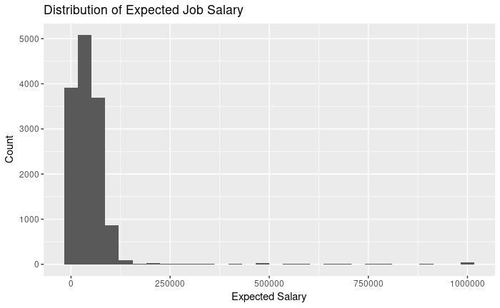

We see there is a number of individuals who are creating a large skew in the expected salary from a job.

```r
raw_data %>%
  rename(money_expect = `About how much money do you expect to earn per year at your first developer job (in US Dollars)?`) %>%
  filter(money_expect > 250000) %>%
  select(money_expect, free_text_cols) %>%
  arrange(desc(money_expect)) %>%
  data.frame() %>%
  describe()
```

```
.

 10  Variables      149  Observations
--------------------------------------------------------------------------------------------
money_expect
       n  missing distinct     Info     Mean      Gmd      .05      .10      .25      .50
     149        0       47    0.983   667365   281704   300000   335992   500000   600000
     .75      .90      .95
  970000  1000000  1000000

lowest :  260000  270000  284839  285881  300000, highest:  950000  970000  991947  999999 1000000
--------------------------------------------------------------------------------------------
Other
       n  missing distinct
       8      141        8

Blockchain Developer (1, 0.125), Computational Biology (1, 0.125), Email specialist (1,
0.125), Robotics (1, 0.125), secret service (1, 0.125), Software engineer (1, 0.125),
Technical Support Specialist (1, 0.125), Technical writer API documentation (1, 0.125)
--------------------------------------------------------------------------------------------
Other_1
       n  missing distinct
       8      141        8

lowest : As a hobby and master coding                                                                                                 Faciliter les taches de la vie                                                                                               I just want to do things like this :)    …
highest: I like computers and programming                                                                                             To get a job in Web Development                                                                                              To help improve the medical conditions of…
--------------------------------------------------------------------------------------------
Other_2
       n  missing distinct
      20      129       18

lowest : Code.org         CodeCademy       Dataquest        Emailgeeks Slack enki
highest: Sololearn        Swam             w3               w3school         W3schools
--------------------------------------------------------------------------------------------
Other_3
       n  missing distinct
      22      127       15

lowest : Android Workshop in my college                                Code in schools.                                              codemguru                                                     just studying in my  home using this site freecodecamp.org :( Kode with Klossy
highest: None                                                          none yet. would like to.                                      not yetattended                                               Real people                                                   tech ladies
```

[output cut: 22 more lines]

```
Proportion                    0.333                    0.333                    0.333
--------------------------------------------------------------------------------------------
Other_7
       n  missing distinct
      15      134       11

a hair stylist (1, 0.067), college student (1, 0.067), contract worker (1, 0.067), fully
studying (1, 0.067), Havent been hired for any as im 15 (1, 0.067), I am a Student (1,
0.067), One year coding program (1, 0.067), Salaried permanent Government employee (1,
0.067), student (1, 0.067), Student (5, 0.333), studying (1, 0.067)
--------------------------------------------------------------------------------------------

Variables with all observations missing:

[1] Other_6
```

There doesn’t appear to be any irrelevant comments from these variables, so we can probably just leave this variable alone in cleaning.

### Check number of hours spent learning

### Check number of months programming

### Check month spent on programming outside of university

### Check distribution of ages

### Check debt owed for home mortgage

### Check debt owed for student debt

### Check “Other” answer for employment status

### Check how much money made last year

### Check distribution of survey completion times

# Check Outlier Rich Columns

# Check Empty Rows

Some entries to the survey may have not be serious. In other words, these individuals may have filled most of the survey but then left the rest of it blank. Here, I test my hypothesis that there are such people.

First we’ll need to calculate how sparse each of the rows are. This should be a simple count the number of `NA` values for each column, with respect to the total number of columns.

```r
# Calculate sparsity of rows
num_cols <- ncol(raw_data)
sparsity_perc <- raw_data %>%
  is.na() %>%
  rowSums() / num_cols
sparsity_perc %>% summary()
```

```
   Min. 1st Qu.  Median    Mean 3rd Qu.    Max.
 0.1333  0.6815  0.7185  0.7177  0.7556  0.9778
```

Looking at these statistics, we can see that there are some rows with the majority of the columns are `NA` values. So we can probably remove these safely.

```r
sparsity_perc %>% stem()
```

```
  The decimal point is 1 digit(s) to the left of the |

  1 | 3
  1 | 7
  2 |
  2 | 679
  3 |
  3 | 568999
  4 | 111122334444
  4 | 5556667777777777788888889999999999999999
  5 | 00000000000000000000111111111111112222222222222223333333333333333333+43
  5 | 55555555555555555555555555555555555555555555555566666666666666666666+555
  6 | 00000000000000000000000000000000000000000000000000000000000000000000+2756
  6 | 55555555555555555555555555555555555555555555555555555555555555555555+6313
  7 | 00000000000000000000000000000000000000000000000000000000000000000000+10989
  7 | 55555555555555555555555555555555555555555555555555555555555555555555+7493
  8 | 00000000000000000000000000000000000000000000000000000000000000000000+1791
  8 | 55555555555555555555555555555555555555555555555555555555555555555555+194
  9 | 00000000000000000000000000000000000000000000000000000000000000000000+117
  9 | 55555555555555566666666666666666666666666666666666666666777777777777+35
```

As a quick-and-dirty visualization, it looks like the majority of the entries are `NA` values, specifically around 70%. This could be because of lots of the multiple answer questions.

But looking at this distribution, even the other extreme is suspicious, namely the very complete entries, where only 13% of the values are empty.

# Distribution of Completion Times

It might be interesting to look at the distribution of completion times. This can be valuable because individuals who finished really quickly, may have put down irrelevant answers that wouldn’t be useful.

```r
completion_time <- raw_data %>%
  select(`Submit Date (UTC)`, `Start Date (UTC)`) %>%
  mutate(total_time_sec = `Submit Date (UTC)` - `Start Date (UTC)`) %>%
  mutate(total_time_min = total_time_sec / 60) %>%
  mutate(total_time_min = as.numeric(total_time_min))
completion_time %>%
  pull(total_time_min) %>%
  stem()
```

```
  The decimal point is 3 digit(s) to the right of the |

   0 | 00000000000000000000000000000000000000000000000000000000000000000000+31000
   1 | 0000000011111111122223333344444444555667889
   2 | 0247889
   3 | 148
   4 | 123344
   5 | 457
   6 | 01
   7 |
   8 | 5
   9 | 78
  10 |
  11 |
  12 |
  13 | 1
  14 | 6
```

There are also individuals who wanted to get through the survey as fast as possible.

```r
completion_time %>%
  filter(total_time_min < 1) %>%
  arrange(total_time_min) %>%
  as.data.frame() %>%
  head()
```

```
    Submit Date (UTC)    Start Date (UTC) total_time_sec total_time_min
1 2018-08-05 17:19:55 2018-08-05 17:19:54         1 secs     0.01666667
2 2018-08-07 18:04:14 2018-08-07 18:04:11         3 secs     0.05000000
3 2018-10-07 19:09:40 2018-10-07 19:09:30        10 secs     0.16666667
4 2018-10-22 23:42:42 2018-10-22 23:42:31        11 secs     0.18333333
5 2018-10-07 19:09:16 2018-10-07 19:09:05        11 secs     0.18333333
6 2018-09-24 19:52:58 2018-09-24 19:52:46        12 secs     0.20000000
```

# Summary of Pre-Processing Data

Here is a summary of what data pre-processing needs to be done.

- Remove ages greater than 116 (and be skeptical of those around that age)